# Creating beautiful tables in R with {gt} - 4 Styling

### 4.1.1 Tab options

Next, we can tweak our table’s appearance with `tab_options()`. It’s basically the analogue of `theme()` in `{ggplot2}`. In Chapter 1, we’ve already used `tab_options()` to apply three small changes. Once again, there’s no harm in applying another layer of the same stuff.

```r
penguins_table |>
  tab_options(
    # These were the ones we applied in the first chapter
    data_row.padding = px(2),
    summary_row.padding = px(3), # A bit more padding for summaries
    row_group.padding = px(4)    # And even more for our groups
  )
```

Penguins in the Palmer Archipelago

Data is courtesy of the {palmerpenguins} R package

|  | **Adelie** Female | **Adelie** Male | **Chinstrap** Female | **Chinstrap** Male | **Gentoo** Female | **Gentoo** Male |
| --- | --- | --- | --- | --- | --- | --- |
| Island: Biscoe |  |  |  |  |  |  |
| 2007 | 5 | 5 | - | - | 16 | 17 |
| 2008 | 9 | 9 | - | - | 22 | 23 |
| 2009 | 8 | 8 | - | - | 20 | 21 |
| Maximum | 9 | 9 | - | - | 22 | 23 |
| Total | 22 | 22 | - | - | 58 | 61 |
| Island: Dream |  |  |  |  |  |  |
| 2007 | 9 | 10 | 13 | 13 | - | - |
| 2008 | 8 | 8 | 9 | 9 | - | - |
| 2009 | 10 | 10 | 12 | 12 | - | - |
| Maximum | 10 | 10 | 13 | 13 | - | - |
| Total | 27 | 28 | 34 | 34 | - | - |
| Island: Torgersen |  |  |  |  |  |  |
| 2007 | 8 | 7 | - | - | - | - |
| 2008 | 8 | 8 | - | - | - | - |
| 2009 | 8 | 8 | - | - | - | - |
| Maximum | 8 | 8 | - | - | - | - |
| Total | 24 | 23 | - | - | - | - |

But let’s change a couple of things. Warning: These changes may or may not “improve” the table. We’ll just apply stuff to learn what’s going on. We can worry about aesthetics later.

We’ll start by styling the heading a little bit. All of the arguments in `tab_options()` that target the header start with `heading.`

```r
penguins_table |>
  tab_options(
    # These were the ones we applied in the first chapter
    data_row.padding = px(2),
    summary_row.padding = px(3), # A bit more padding for summaries
    row_group.padding = px(4)    # And even more for our groups
  ) |>
  # Change header theme
  tab_options(
    heading.align = 'left',
    heading.background.color = 'darkgreen',
    heading.title.font.size = px(20)
  )
```

Penguins in the Palmer Archipelago

Data is courtesy of the {palmerpenguins} R package

|  | **Adelie** Female | **Adelie** Male | **Chinstrap** Female | **Chinstrap** Male | **Gentoo** Female | **Gentoo** Male |
| --- | --- | --- | --- | --- | --- | --- |
| Island: Biscoe |  |  |  |  |  |  |
| 2007 | 5 | 5 | - | - | 16 | 17 |
| 2008 | 9 | 9 | - | - | 22 | 23 |
| 2009 | 8 | 8 | - | - | 20 | 21 |
| Maximum | 9 | 9 | - | - | 22 | 23 |
| Total | 22 | 22 | - | - | 58 | 61 |
| Island: Dream |  |  |  |  |  |  |
| 2007 | 9 | 10 | 13 | 13 | - | - |
| 2008 | 8 | 8 | 9 | 9 | - | - |
| 2009 | 10 | 10 | 12 | 12 | - | - |
| Maximum | 10 | 10 | 13 | 13 | - | - |
| Total | 27 | 28 | 34 | 34 | - | - |
| Island: Torgersen |  |  |  |  |  |  |
| 2007 | 8 | 7 | - | - | - | - |
| 2008 | 8 | 8 | - | - | - | - |
| 2009 | 8 | 8 | - | - | - | - |
| Maximum | 8 | 8 | - | - | - | - |
| Total | 24 | 23 | - | - | - | - |

Next, let us attack our column labels. We’ll do two things:

1. Change the background color (simple)
2. Remove the bottom border line (A bit tricky. You’ll see why in a sec.)

To achieve the latter thing, you need to change `border-style`. The most common are `solid`, `dashed`, `dotted` and `none`. Guess which one we’re choosing.

```r
penguins_table |>
  tab_options(
    # These were the ones we applied in the first chapter
    data_row.padding = px(2),
    summary_row.padding = px(3), # A bit more padding for summaries
    row_group.padding = px(4)    # And even more for our groups
  ) |>
  # Change header theme
  tab_options(
    heading.align = 'left',
    heading.background.color = 'darkgreen',
    heading.title.font.size = px(20)
  ) |>
  tab_options(
    column_labels.background.color = 'yellow',
    column_labels.border.bottom.style = 'none'
  )
```

Penguins in the Palmer Archipelago

Data is courtesy of the {palmerpenguins} R package

|  | **Adelie** Female | **Adelie** Male | **Chinstrap** Female | **Chinstrap** Male | **Gentoo** Female | **Gentoo** Male |
| --- | --- | --- | --- | --- | --- | --- |
| Island: Biscoe |  |  |  |  |  |  |
| 2007 | 5 | 5 | - | - | 16 | 17 |
| 2008 | 9 | 9 | - | - | 22 | 23 |
| 2009 | 8 | 8 | - | - | 20 | 21 |
| Maximum | 9 | 9 | - | - | 22 | 23 |
| Total | 22 | 22 | - | - | 58 | 61 |
| Island: Dream |  |  |  |  |  |  |
| 2007 | 9 | 10 | 13 | 13 | - | - |
| 2008 | 8 | 8 | 9 | 9 | - | - |
| 2009 | 10 | 10 | 12 | 12 | - | - |
| Maximum | 10 | 10 | 13 | 13 | - | - |
| Total | 27 | 28 | 34 | 34 | - | - |
| Island: Torgersen |  |  |  |  |  |  |
| 2007 | 8 | 7 | - | - | - | - |
| 2008 | 8 | 8 | - | - | - | - |
| 2009 | 8 | 8 | - | - | - | - |
| Maximum | 8 | 8 | - | - | - | - |
| Total | 24 | 23 | - | - | - | - |

The effect of the color change is clearly visible. But what’s that? There is still a line below the column labels. The reason for this is simple: There is no border below the `column_labels` area anymore. But there is still a border above the `table_body` and the `row_group`. Yes, that’s right. You can only remove one line at the cost of three[^1].

```r
penguins_table |>
  tab_options(
    # These were the ones we applied in the first chapter
    data_row.padding = px(2),
    summary_row.padding = px(3), # A bit more padding for summaries
    row_group.padding = px(4)    # And even more for our groups
  ) |>
  # Change header theme
  tab_options(
    heading.align = 'left',
    heading.background.color = 'darkgreen',
    heading.title.font.size = px(20)
  ) |>
  tab_options(
    column_labels.background.color = 'yellow',
    column_labels.border.bottom.style = 'none',
    row_group.border.top.style = 'none',
    table_body.border.top.style = 'none'
  )
```

Penguins in the Palmer Archipelago

Data is courtesy of the {palmerpenguins} R package

|  | **Adelie** Female | **Adelie** Male | **Chinstrap** Female | **Chinstrap** Male | **Gentoo** Female | **Gentoo** Male |
| --- | --- | --- | --- | --- | --- | --- |
| Island: Biscoe |  |  |  |  |  |  |
| 2007 | 5 | 5 | - | - | 16 | 17 |
| 2008 | 9 | 9 | - | - | 22 | 23 |
| 2009 | 8 | 8 | - | - | 20 | 21 |
| Maximum | 9 | 9 | - | - | 22 | 23 |
| Total | 22 | 22 | - | - | 58 | 61 |
| Island: Dream |  |  |  |  |  |  |
| 2007 | 9 | 10 | 13 | 13 | - | - |
| 2008 | 8 | 8 | 9 | 9 | - | - |
| 2009 | 10 | 10 | 12 | 12 | - | - |
| Maximum | 10 | 10 | 13 | 13 | - | - |
| Total | 27 | 28 | 34 | 34 | - | - |
| Island: Torgersen |  |  |  |  |  |  |
| 2007 | 8 | 7 | - | - | - | - |
| 2008 | 8 | 8 | - | - | - | - |
| 2009 | 8 | 8 | - | - | - | - |
| Maximum | 8 | 8 | - | - | - | - |
| Total | 24 | 23 | - | - | - | - |

So how do you find out which areas might affect whatever it is that you want to style? Lucky for us, the [gt docs](https://gt.rstudio.com/index.html) have a neat image that shows you the areas of a `{gt}` table.

[figure not shown]

Figure 4.1: This figure is taken straight form the [gt docs](https://gt.rstudio.com/index.html). I didn’t find a license for this image. But I hope it’s cool if I use it. Please let me know if not.

There’s one more way to find out what border you need to overwrite and we’ll talk about it in Section 4.2. For now, let me show you how you can target even more specific parts of your table.

### 4.1.2 Cell styling

Imagine that you want to turn the Chinstrap column spanner blue (for whatever reason). You have seen that you can target only all column labels and all column spanners with `tab_options()`. For very specific wishes (like this one), there’s `tab_style()`.

This function has two arguments: `locations` and `style`. Does this remind you of something? That’s right, it’s very similar to `text_transform()` which you learned in Chapter 2. But instead of applying a text transformation function to a cell, we apply a style.

Now, to specify `locations` and `style` we have two sets of helper functions. The location helpers translate more or less to the areas that you see in Figure 4.1.

#### Location helpers

- `cells_body()`
- `cells_column_labels()`
- `cells_column_spanners()`
- `cells_footnotes()`
- `cells_grand_summary()`
- `cells_row_groups()`
- `cells_stub()`
- `cells_stub_grand_summary()`
- `cells_stub_summary()`
- `cells_stubhead()`
- `cells_summary()`
- `cells_title()`

#### Style helpers

- `cell_borders()`
- `cell_fill()`
- `cell_text()`

Applying these helpers is pretty straightforward. Just use them for either `locations` or `style` in `tab_style()`. For example, we can use `cells_column_spanners()` to target all column spanners. And with `cell_fill()` we can turn them blue.

```r
penguins_table |>
  tab_options(
    # These were the ones we applied in the first chapter
    data_row.padding = px(2),
    summary_row.padding = px(3), # A bit more padding for summaries
    row_group.padding = px(4)    # And even more for our groups
  ) |>
  # Change header theme
  tab_options(
    heading.align = 'left',
    heading.background.color = 'darkgreen',
    heading.title.font.size = px(20)
  ) |>
  tab_options(
    column_labels.background.color = 'yellow',
    column_labels.border.bottom.style = 'none',
    row_group.border.top.style = 'none',
    table_body.border.top.style = 'none'
  ) |>
  tab_style(
    locations = cells_column_spanners(),
    style = cell_fill(color = 'dodgerblue')
  )
```

Penguins in the Palmer Archipelago

Data is courtesy of the {palmerpenguins} R package

|  | **Adelie** Female | **Adelie** Male | **Chinstrap** Female | **Chinstrap** Male | **Gentoo** Female | **Gentoo** Male |
| --- | --- | --- | --- | --- | --- | --- |
| Island: Biscoe |  |  |  |  |  |  |
| 2007 | 5 | 5 | - | - | 16 | 17 |
| 2008 | 9 | 9 | - | - | 22 | 23 |
| 2009 | 8 | 8 | - | - | 20 | 21 |
| Maximum | 9 | 9 | - | - | 22 | 23 |
| Total | 22 | 22 | - | - | 58 | 61 |
| Island: Dream |  |  |  |  |  |  |
| 2007 | 9 | 10 | 13 | 13 | - | - |
| 2008 | 8 | 8 | 9 | 9 | - | - |
| 2009 | 10 | 10 | 12 | 12 | - | - |
| Maximum | 10 | 10 | 13 | 13 | - | - |
| Total | 27 | 28 | 34 | 34 | - | - |
| Island: Torgersen |  |  |  |  |  |  |
| 2007 | 8 | 7 | - | - | - | - |
| 2008 | 8 | 8 | - | - | - | - |
| 2009 | 8 | 8 | - | - | - | - |
| Maximum | 8 | 8 | - | - | - | - |
| Total | 24 | 23 | - | - | - | - |

Another cool way to target cells is `tab_style_body()`. Basically, it is a combination of `fmt()` from Chapter 3 and `tab_style()`. So, you can apply a style to table cells that either match a regex, correspond to a specific value or fulfill criteria according to your own custom function. Here’s one example of that.

```r
penguins_table |>
  tab_options(
    # These were the ones we applied in the first chapter
    data_row.padding = px(2),
    summary_row.padding = px(3), # A bit more padding for summaries
    row_group.padding = px(4)    # And even more for our groups
  ) |>
  # Change header theme
  tab_options(
    heading.align = 'left',
    heading.background.color = 'darkgreen',
    heading.title.font.size = px(20)
  ) |>
  tab_options(
    column_labels.background.color = 'yellow',
    column_labels.border.bottom.style = 'none',
    row_group.border.top.style = 'none',
    table_body.border.top.style = 'none'
  ) |>
  tab_style(
    locations = cells_column_spanners(),
    style = cell_fill(color = 'dodgerblue')
  ) |>
  tab_style_body(
    fn = function(x) between(x, 5, 10),
    style = cell_text(color = 'red', weight = 'bold')
  )
```

Penguins in the Palmer Archipelago

Data is courtesy of the {palmerpenguins} R package

|  | **Adelie** Female | **Adelie** Male | **Chinstrap** Female | **Chinstrap** Male | **Gentoo** Female | **Gentoo** Male |
| --- | --- | --- | --- | --- | --- | --- |
| Island: Biscoe |  |  |  |  |  |  |
| 2007 | 5 | 5 | - | - | 16 | 17 |
| 2008 | 9 | 9 | - | - | 22 | 23 |
| 2009 | 8 | 8 | - | - | 20 | 21 |
| Maximum | 9 | 9 | - | - | 22 | 23 |
| Total | 22 | 22 | - | - | 58 | 61 |
| Island: Dream |  |  |  |  |  |  |
| 2007 | 9 | 10 | 13 | 13 | - | - |
| 2008 | 8 | 8 | 9 | 9 | - | - |
| 2009 | 10 | 10 | 12 | 12 | - | - |
| Maximum | 10 | 10 | 13 | 13 | - | - |
| Total | 27 | 28 | 34 | 34 | - | - |
| Island: Torgersen |  |  |  |  |  |  |
| 2007 | 8 | 7 | - | - | - | - |
| 2008 | 8 | 8 | - | - | - | - |
| 2009 | 8 | 8 | - | - | - | - |
| Maximum | 8 | 8 | - | - | - | - |
| Total | 24 | 23 | - | - | - | - |

Unfortunately, this function works only on cells in the body. Thus we have to find some other way to target the Chinstrap column spanner. To make this work, we have to assign an ID to the column spanner. Then, we can target that ID within `cells_column_spanners()`. Here’s a minimal example of how that works.

```r
exibble |>
  select(1:4) |>
  gt() |>
  opt_stylize(style = 3) |>
  fmt_number(columns = 'num') |>
  tab_spanner(
    columns = 1:2,
    label = 'A column spanner',
    id = 'spannerA' ## That's the ID we can target
  ) |>
  tab_spanner(
    columns = 3:4,
    label = 'Another column spanner',
    id = 'spannerB' ## That's the ID we can target
  )  |>
  tab_style(
    locations = cells_column_spanners(spanners = 'spannerA'),
    style = cell_fill(color = 'darkgreen')
  ) |>
  tab_style(
    locations = cells_column_spanners(spanners = 'spannerB'),
    style = cell_fill(color = 'darkgreen', alpha = 0.5)
  )
```

| A column spanner num | A column spanner char | Another column spanner fctr | Another column spanner date |
| --- | --- | --- | --- |
| 0.11 | apricot | one | 2015-01-15 |
| 2.22 | banana | two | 2015-02-15 |
| 33.33 | coconut | three | 2015-03-15 |
| 444.40 | durian | four | 2015-04-15 |
| 5,550.00 | NA | five | 2015-05-15 |
| NA | fig | six | 2015-06-15 |
| 777,000.00 | grapefruit | seven | NA |
| 8,880,000.00 | honeydew | eight | 2015-08-15 |

```r
penguin_counts_wider |>
  mutate(across(.cols = -(1:2), ~if_else(. == 0, NA_integer_, .))) |>
  mutate(
    island = as.character(island),
    year = as.numeric(year),
    island = paste0('Island: ', island)
  ) |>
  gt(groupname_col = 'island', rowname_col = 'year') |>
  cols_label(.list = desired_colnames) |>
  tab_spanner(
    label = md('**Adelie**'),
    columns = 3:4
  ) |>
  tab_spanner(
    label = md('**Chinstrap**'),
    columns = c('Chinstrap_female', 'Chinstrap_male'),
    id = 'chinstrap'
  ) |>
  tab_spanner(
    label =  md('**Gentoo**'),
    columns = contains('Gentoo')
  ) |>
  tab_header(
    title = 'Penguins in the Palmer Archipelago',
    subtitle = 'Data is courtesy of the {palmerpenguins} R package'
  ) |>
  sub_missing(missing_text = '-') |>
  summary_rows(
    groups = TRUE,
    fns = list(
      'Maximum' = ~max(.),
      'Total' = ~sum(.)
    ),
    formatter = fmt_number,
    decimals = 0,
    missing_text = '-'
  )  |>
  tab_options(
    data_row.padding = px(2),
    summary_row.padding = px(3), # A bit more padding for summaries
    row_group.padding = px(4)    # And even more for our groups
  ) |>
  opt_stylize(style = 6, color = 'gray') |>
  tab_style(
    locations = cells_column_spanners(spanners = 'chinstrap'),
    style = cell_fill(color = 'dodgerblue')
  )
```

Penguins in the Palmer Archipelago

Data is courtesy of the {palmerpenguins} R package

|  | **Adelie** Female | **Adelie** Male | **Chinstrap** Female | **Chinstrap** Male | **Gentoo** Female | **Gentoo** Male |
| --- | --- | --- | --- | --- | --- | --- |
| Island: Biscoe |  |  |  |  |  |  |
| 2007 | 5 | 5 | - | - | 16 | 17 |
| 2008 | 9 | 9 | - | - | 22 | 23 |
| 2009 | 8 | 8 | - | - | 20 | 21 |
| Maximum | 9 | 9 | - | - | 22 | 23 |
| Total | 22 | 22 | - | - | 58 | 61 |
| Island: Dream |  |  |  |  |  |  |
| 2007 | 9 | 10 | 13 | 13 | - | - |
| 2008 | 8 | 8 | 9 | 9 | - | - |
| 2009 | 10 | 10 | 12 | 12 | - | - |
| Maximum | 10 | 10 | 13 | 13 | - | - |
| Total | 27 | 28 | 34 | 34 | - | - |
| Island: Torgersen |  |  |  |  |  |  |
| 2007 | 8 | 7 | - | - | - | - |
| 2008 | 8 | 8 | - | - | - | - |
| 2009 | 8 | 8 | - | - | - | - |
| Maximum | 8 | 8 | - | - | - | - |
| Total | 24 | 23 | - | - | - | - |

Notice that the grey border at the bottom of the Chinstrap column spanner looks kind of ugly. So, why not remove it? This is a great exercise of applying multiple styles. This is done by using multiple style helpers and collecting them in a list. The same works with location helpers. Here’s a small example again.

```r
exibble |>
  select(1:4) |>
  gt() |>
  opt_stylize(style = 3) |>
  fmt_number(columns = 'num') |>
  tab_spanner(
    columns = 1:2,
    label = 'A column spanner',
    id = 'spannerA'
  ) |>
  tab_spanner(
    columns = 3:4,
    label = 'Another column spanner',
    id = 'spannerB'
  )  |>
  tab_style(
    locations = cells_column_spanners(spanners = 'spannerA'),
    style = cell_fill(color = 'darkgreen')
  ) |>
  tab_style(
    locations = cells_column_spanners(spanners = 'spannerB'),
    style = cell_fill(color = 'darkgreen', alpha = 0.5)
  ) |>
  tab_style(
    locations = list(
      cells_column_labels(),
      cells_body(
        columns = c('char', 'date'), rows = c(3, 5, 8)
      )
    ),
    style = list(
      cell_fill(color = 'firebrick4'),
      cell_text(color = 'white', size = 14, weight = 'bold'),
      cell_borders(
        sides = c('left', 'right'),
        color = 'green',
        weight = px(3)
      )
    )
  )
```

| A column spanner num | A column spanner char | Another column spanner fctr | Another column spanner date |
| --- | --- | --- | --- |
| 0.11 | apricot | one | 2015-01-15 |
| 2.22 | banana | two | 2015-02-15 |
| 33.33 | coconut | three | 2015-03-15 |
| 444.40 | durian | four | 2015-04-15 |
| 5,550.00 | NA | five | 2015-05-15 |
| NA | fig | six | 2015-06-15 |
| 777,000.00 | grapefruit | seven | NA |
| 8,880,000.00 | honeydew | eight | 2015-08-15 |

Now, applying the same logic to our Chinstrap column spanner should be easy, right? It is. But unfortunately, it didn’t help. Have a look for yourself. The border is still there.

```r
penguin_counts_wider |>
  mutate(across(.cols = -(1:2), ~if_else(. == 0, NA_integer_, .))) |>
  mutate(
    island = as.character(island),
    year = as.numeric(year),
    island = paste0('Island: ', island)
  ) |>
  gt(groupname_col = 'island', rowname_col = 'year') |>
  cols_label(.list = desired_colnames) |>
  tab_spanner(
    label = md('**Adelie**'),
    columns = 3:4
  ) |>
  tab_spanner(
    label = md('**Chinstrap**'),
    columns = c('Chinstrap_female', 'Chinstrap_male'),
    id = 'chinstrap'
  ) |>
  tab_spanner(
    label =  md('**Gentoo**'),
    columns = contains('Gentoo')
  ) |>
  tab_header(
    title = 'Penguins in the Palmer Archipelago',
    subtitle = 'Data is courtesy of the {palmerpenguins} R package'
  ) |>
  sub_missing(missing_text = '-') |>
  summary_rows(
    groups = TRUE,
    fns = list(
      'Maximum' = ~max(.),
      'Total' = ~sum(.)
    ),
    formatter = fmt_number,
    decimals = 0,
    missing_text = '-'
  )  |>
  tab_options(
    data_row.padding = px(2),
    summary_row.padding = px(3), # A bit more padding for summaries
    row_group.padding = px(4)    # And even more for our groups
  ) |>
  opt_stylize(style = 6, color = 'gray') |>
  tab_style(
    locations = cells_column_spanners(spanners = 'chinstrap'),
    style = list(
      cell_fill(color = 'dodgerblue'),
      cell_borders(style = 'hidden')
    )
  )
```

Penguins in the Palmer Archipelago

Data is courtesy of the {palmerpenguins} R package

|  | **Adelie** Female | **Adelie** Male | **Chinstrap** Female | **Chinstrap** Male | **Gentoo** Female | **Gentoo** Male |
| --- | --- | --- | --- | --- | --- | --- |
| Island: Biscoe |  |  |  |  |  |  |
| 2007 | 5 | 5 | - | - | 16 | 17 |
| 2008 | 9 | 9 | - | - | 22 | 23 |
| 2009 | 8 | 8 | - | - | 20 | 21 |
| Maximum | 9 | 9 | - | - | 22 | 23 |
| Total | 22 | 22 | - | - | 58 | 61 |
| Island: Dream |  |  |  |  |  |  |
| 2007 | 9 | 10 | 13 | 13 | - | - |
| 2008 | 8 | 8 | 9 | 9 | - | - |
| 2009 | 10 | 10 | 12 | 12 | - | - |
| Maximum | 10 | 10 | 13 | 13 | - | - |
| Total | 27 | 28 | 34 | 34 | - | - |
| Island: Torgersen |  |  |  |  |  |  |
| 2007 | 8 | 7 | - | - | - | - |
| 2008 | 8 | 8 | - | - | - | - |
| 2009 | 8 | 8 | - | - | - | - |
| Maximum | 8 | 8 | - | - | - | - |
| Total | 24 | 23 | - | - | - | - |

The reason why this is happening is simple. It’s a [known bug](https://github.com/rstudio/gt/issues/648). But that’s not a problem. Actually, that’s a great motivation for our next part.

Whenever styling does not work as expected, `{gt}` allows you to sneak behind the HTML/CSS curtain. Then, you can manually apply whatever it is you want to apply.

I know that this may sound daunting but it’s actually quite manageable. I’ve learned most of what I know about HTML/CSS from [styling my Quarto blog](https://www.youtube.com/watch?v=ErRX8plZpQE). And most of that happened via copy-and-paste. With a little bit of effort, you can do the same.

## 4.2 Custom CSS

Let’s do a HTML/CSS quick tour. First, let us start with something you’re already familiar with. You probably know that Markdown converts `**blabla**` to **blabla**, i.e. bold text. This means that with the right decoration, you can turn `blabla` into bold non-sense.

### 4.2.1 Tags and their styling

The idea is the same for HTML/CSS. With the right decoration, you can transform any text into something else. The cool thing is that with HTML/CSS you can do more than “just” bold text. You have way more options to transform your text.

Unfortunately, this power comes with a more verbose notation. For example, for bold inline text you could wrap `blabla` into `<span style="font-weight:bold;">...</span>`. In this case, `<span>...</span>` is just the tag to use inline text. This is not a particularly sexy thing to write. But it gives you the power to change more than just the font-weight inside the span tags.

You could add styles as you see fit. For example, you continue the list within `style=` by adding. `color:blue;`, `font-family:Merriweather;`….and so on.

Of course, there are not only `<span>` tags. For example, there’s `<p>` for paragraphs, `<a>` for hyperlinks and `<div>` for sections aka divisions. In our case there’s one more important tag that `{gt}` uses: `<table>`.

### 4.2.2 Classes and IDs

Just like your Markdown documents, websites are really just decorated texts. Every little tweak on a website can be accomplished by adding the right instruction into `style=`.

Now, comes the good part. You don’t have to repeat your style instructions all the time. You can recycle your styles. That’s what CSS classes do.

Let’s imagine that we want to recycle our previous style that used `color:blue;`, `font-family:Merriweather;` and `font-weight:bold;`. We can define a CSS class `my-style` that encodes that information as follows.

```css
.my-style {
  color:blue;
  font-family:Merriweather;
  font-weight:bold;
}
```

Notice the `.` at the beginning. That’s the secret class symbol in CSS. And that’s also the only thing we need to know to overwrite the `gt_table` class to style our table like we want. The `opt_css()` layer will help us to get the CSS code into our website.

```r
library(gt)
exibble |>
  gt() |>
  opt_css(
    '
    .gt_table {
      color:blue;
      font-family:Merriweather;
      font-weight:bold;
    }
    '
  )
```

| num | char | fctr | date | time | datetime | currency | row | group |
| --- | --- | --- | --- | --- | --- | --- | --- | --- |
| 1.111e-01 | apricot | one | 2015-01-15 | 13:35 | 2018-01-01 02:22 | 49.950 | row_1 | grp_a |
| 2.222e+00 | banana | two | 2015-02-15 | 14:40 | 2018-02-02 14:33 | 17.950 | row_2 | grp_a |
| 3.333e+01 | coconut | three | 2015-03-15 | 15:45 | 2018-03-03 03:44 | 1.390 | row_3 | grp_a |
| 4.444e+02 | durian | four | 2015-04-15 | 16:50 | 2018-04-04 15:55 | 65100.000 | row_4 | grp_a |
| 5.550e+03 | NA | five | 2015-05-15 | 17:55 | 2018-05-05 04:00 | 1325.810 | row_5 | grp_b |
| NA | fig | six | 2015-06-15 | NA | 2018-06-06 16:11 | 13.255 | row_6 | grp_b |
| 7.770e+05 | grapefruit | seven | NA | 19:10 | 2018-07-07 05:22 | NA | row_7 | grp_b |
| 8.880e+06 | honeydew | eight | 2015-08-15 | 20:20 | NA | 0.440 | row_8 | grp_b |

Unfortunately, this did not change anything. Why? Because `{gt}` is clever enough to encode its styling not only with a global CSS class like `.gt_table` but also with a unique ID for every table. This ensures that you cannot accidentally change the styling of a different `{gt}` table.

That’s why you can assign a custom ID for your table in `gt()` and target that ID in your CSS code. The secret symbol for IDs in CSS is `#`. Armed with that knowledge, let us try again.

```r
library(gt)
exibble |>
  gt(id = 'table_id') |>
  opt_css(
    '
    #table_id .gt_table {
      color:blue;
      font-family:Merriweather;
      font-weight:bold;
    }
    '
  )
```

| num | char | fctr | date | time | datetime | currency | row | group |
| --- | --- | --- | --- | --- | --- | --- | --- | --- |
| 1.111e-01 | apricot | one | 2015-01-15 | 13:35 | 2018-01-01 02:22 | 49.950 | row_1 | grp_a |
| 2.222e+00 | banana | two | 2015-02-15 | 14:40 | 2018-02-02 14:33 | 17.950 | row_2 | grp_a |
| 3.333e+01 | coconut | three | 2015-03-15 | 15:45 | 2018-03-03 03:44 | 1.390 | row_3 | grp_a |
| 4.444e+02 | durian | four | 2015-04-15 | 16:50 | 2018-04-04 15:55 | 65100.000 | row_4 | grp_a |
| 5.550e+03 | NA | five | 2015-05-15 | 17:55 | 2018-05-05 04:00 | 1325.810 | row_5 | grp_b |
| NA | fig | six | 2015-06-15 | NA | 2018-06-06 16:11 | 13.255 | row_6 | grp_b |
| 7.770e+05 | grapefruit | seven | NA | 19:10 | 2018-07-07 05:22 | NA | row_7 | grp_b |
| 8.880e+06 | honeydew | eight | 2015-08-15 | 20:20 | NA | 0.440 | row_8 | grp_b |

Awesome. This worked. At least a bit. But the column labels remained the same. Here’s why.

The things that we want to change (`color`, `font-family` and `font-weight` of the column labels) are not styled in the `.gt_table` class. These are styled in `.gt_col_heading`.

Hence, you need to target that class as well. Maybe with different instructions.

```r
exibble |>
  gt(id = 'table_id') |>
  opt_css(
    '
    #table_id .gt_table {
      color:blue;
      font-family:Merriweather;
      font-weight:bold;
    }

    #table_id .gt_col_heading {
      color:red;
      font-family:"Source Sans Pro";
      font-weight:bold;
    }
    '
  )
```

| num | char | fctr | date | time | datetime | currency | row | group |
| --- | --- | --- | --- | --- | --- | --- | --- | --- |
| 1.111e-01 | apricot | one | 2015-01-15 | 13:35 | 2018-01-01 02:22 | 49.950 | row_1 | grp_a |
| 2.222e+00 | banana | two | 2015-02-15 | 14:40 | 2018-02-02 14:33 | 17.950 | row_2 | grp_a |
| 3.333e+01 | coconut | three | 2015-03-15 | 15:45 | 2018-03-03 03:44 | 1.390 | row_3 | grp_a |
| 4.444e+02 | durian | four | 2015-04-15 | 16:50 | 2018-04-04 15:55 | 65100.000 | row_4 | grp_a |
| 5.550e+03 | NA | five | 2015-05-15 | 17:55 | 2018-05-05 04:00 | 1325.810 | row_5 | grp_b |
| NA | fig | six | 2015-06-15 | NA | 2018-06-06 16:11 | 13.255 | row_6 | grp_b |
| 7.770e+05 | grapefruit | seven | NA | 19:10 | 2018-07-07 05:22 | NA | row_7 | grp_b |
| 8.880e+06 | honeydew | eight | 2015-08-15 | 20:20 | NA | 0.440 | row_8 | grp_b |

You’d think that if you target the `.gt_table` class you’d also target the `.gt_col_heading` class. You know, because column headings are part of a table. But that’s not how CSS works. If you want to overwrite existing classes, you need to target the most specific one.

So, how do you find out which one is the right class to target? The short answer is: Check it with your browser. On any website, you can right-click anywhere and then hit “Inspect”. This will open the HTML and CSS code of the current website.

Just use that on the website that displays your current table. In RStudio, I recommend that you hit the “Show in new window” button in the viewer panel. This will open your table in your default browser and then you can take a look at the table’s code.

And I know that what you see after you hit “Inspect” can really confusing if you’ve never worked with HTML or CSS before. Here’s a video that can help you. I recorded this to help readers style their Quarto blog but the same principles apply here.

[video not shown]

In this video, you can probably skip straight to 05:48 if you want to recap the HTML/CSS intro. Or you can skip to 10:28 if you just want to know how to navigate the code.

So, let us put our new-found knowledge into practice. Let’s do something that we couldn’t do before, i.e adding a color gradient. We will apply it to our brands table from Chapter 2. Remember that one? Here it is again.

```r
brands <- tibble(
  Brand = c('twitter', 'facebook', 'linkedin', 'github'),
  color = c('#1DA1F2', '#4267B2', '#0077B5', '#333' )
) |>
  mutate(
# Apply fa() function with all values from columns Brand and color
    Emoji = map2(Brand, color, ~fontawesome::fa(.x, fill = .y)),
# Apply html() function to previous results
    Emoji = map(Emoji, html),
    Brand = str_to_title(Brand)
  ) |>
  select(-color)

brands |>
  gt(id = 'brands-tbl') |>
  tab_header(
    title = 'Brand table',
    subtitle = 'Icons are taken from the {fontawesome} package'
  )  |>
  tab_style(
    style = list(cell_text(size = px(25))),
    locations = cells_body(columns = 'Emoji')
  )
```

Brand table

Icons are taken from the {fontawesome} package

| Brand | Emoji |
| --- | --- |
| Twitter |  |
| Facebook |  |
| Linkedin |  |
| Github |  |

To use a color gradient, we can target the `.gt_table` class and set its `background`. The CSS-code for a linear gradient is `linear-gradient()`. Shocker, I know! It requires an angle, e.g. `135deg`, and two colors.

```r
brands |>
  gt(id = 'brands-tbl') |>
  tab_header(
    title = 'Brand table',
    subtitle = 'Icons are taken from the {fontawesome} package'
  )  |>
# This part makes emojis larger
  tab_style(
    style = list(cell_text(size = px(25))),
    locations = cells_body(columns = 'Emoji')
  ) |>
  opt_css(
    css = '
    #brands-tbl .gt_table {
      background: linear-gradient(135deg, #FFFB7D, #9599E2);
    }
    '
  )
```

Brand table

Icons are taken from the {fontawesome} package

| Brand | Emoji |
| --- | --- |
| Twitter |  |
| Facebook |  |
| Linkedin |  |
| Github |  |

This worked almost as expected. The trick to color the full table is to target the column headings and the table heading and make their background transparent.

```r
brands |>
  gt(id = 'brands-tbl') |>
  tab_header(
    title = 'Brand table',
    subtitle = 'Icons are taken from the {fontawesome} package'
  )  |>
# This part makes emojis larger
  tab_style(
    style = list(cell_text(size = px(25))),
    locations = cells_body(columns = 'Emoji')
  ) |>
  opt_css(
    css = '
    #brands-tbl .gt_table {
      background: linear-gradient(135deg, #FFFB7D, #9599E2);
    }

     #brands-tbl .gt_heading, #brands-tbl .gt_col_heading {
        background:transparent;
      }
    '
  )
```

Brand table

Icons are taken from the {fontawesome} package

| Brand | Emoji |
| --- | --- |
| Twitter |  |
| Facebook |  |
| Linkedin |  |
| Github |  |

Are color gradients useful for a table? I don’t know. But I think they look fancy. So here’s another familiar table restyled with a color gradient.

Species

Penguin's weight

Min

Mean

Max

Distribution

Adelie

2850

3706.16

4775

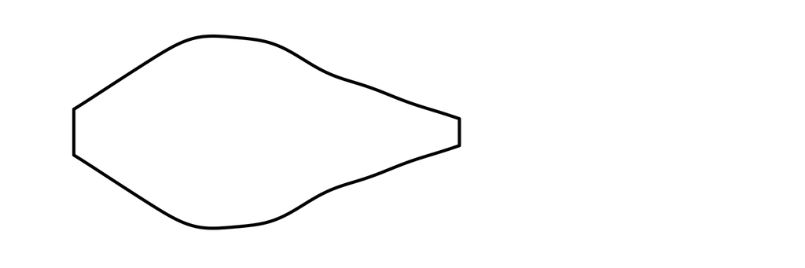

Chinstrap

2700

3733.09

4800

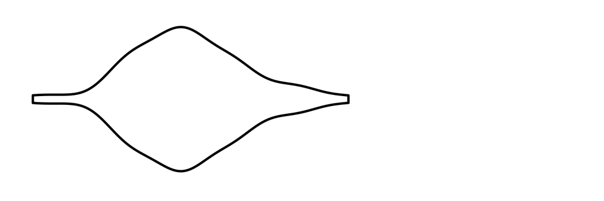

Gentoo

3950

5092.44

6300

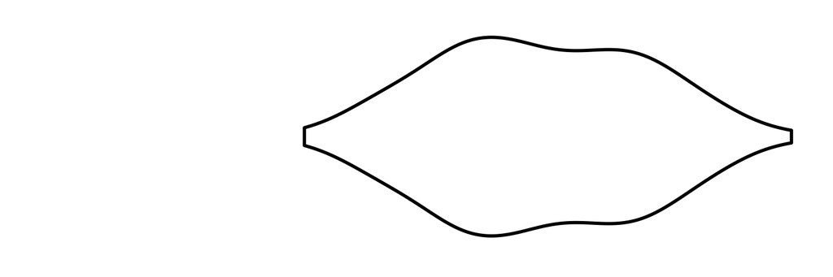

```r
library(tidyverse)
library(gt)

filtered_penguins <- palmerpenguins::penguins |>
    filter(!is.na(sex))

penguin_weights <- palmerpenguins::penguins |>
  filter(!is.na(sex)) |>
  group_by(species) |>
  summarise(
    Min = min(body_mass_g),
    Mean = mean(body_mass_g) |> round(digits = 2),
    Max = max(body_mass_g)
  ) |>
  mutate(species = as.character(species), Distribution = species) |>
  rename(Species = species)

plot_density_species_gradient <- function(species, variable) {
  full_range <- filtered_penguins |>
    pull({{variable}}) |>
    range()

  filtered_penguins |>
    filter(species == !!species) |>
    ggplot(aes(x = {{variable}}, y = species)) +
    geom_violin(fill = 'white', col = 'black', linewidth = 2) +
    theme_minimal() +
    scale_y_discrete(breaks = NULL) +
    scale_x_continuous(breaks = NULL) +
    labs(x = element_blank(), y = element_blank()) +
    coord_cartesian(xlim = full_range)
}

penguin_weights |>
  gt(id = 'weights-tbl') |>
  tab_spanner(
    label = 'Penguin\'s weight',
    columns = -Species
  ) |>
  text_transform(
    locations = cells_body(columns = 'Distribution'),
    # Create a function that takes the a column as input
    # and gives a list of ggplots as output
    fn = function(column) {
      map(column, ~plot_density_species_gradient(., body_mass_g)) |>
        ggplot_image(height = px(50), aspect_ratio = 3)
    }
  ) |>
  cols_align(
    align = 'center',
    columns = 'Distribution'
  ) |>
  tab_options(
    table.font.names = 'Merriweather',
    table.font.color = 'white',
    heading.align = 'left',
    table_body.hlines.width = px(1),
    table_body.hlines.color =  'white',
    table_body.border.top.color = 'white',
    table_body.border.top.style = px(1),
    heading.border.bottom.width = px(1),
    heading.border.bottom.color =  'white',
    column_labels.border.bottom.width = px(1),
    column_labels.border.bottom.color =  'white',
    column_labels.font.weight = 'bold',
    table.border.top.style = 'none',
    table_body.border.bottom.color = 'white'
  ) |>
  opt_css(
    css = '
    #weights-tbl .gt_table {
      background: linear-gradient(-135deg, #c31432, #240b36);
    }

    #weights-tbl .gt_heading, #weights-tbl .gt_col_heading, #weights-tbl .gt_column_spanner_outer {
      background:transparent;
    }

    #weights-tbl .gt_col_headings {
      border-top-color: white;
      border-top-width:1px;
    }

    '
  )
```

Finally, we can fix our penguin table from before. This will require another little CSS trick. The problem that prevented us to from erasing the spanner’s bottom border was this bug: The actual cell that we need to target is nested inside the cell that we targeted with `tab_style()`. Hence, our changes with `tab_style()` are not precise enough to change anything. Thus, the only way to circumvent the bug is to target the correct cell with CSS. Let’s do that for our dummy example first.

| A column spanner num | A column spanner char | Another column spanner fctr | Another column spanner date |
| --- | --- | --- | --- |
| 0.11 | apricot | one | 2015-01-15 |
| 2.22 | banana | two | 2015-02-15 |
| 33.33 | coconut | three | 2015-03-15 |
| 444.40 | durian | four | 2015-04-15 |
| 5,550.00 | NA | five | 2015-05-15 |
| NA | fig | six | 2015-06-15 |
| 777,000.00 | grapefruit | seven | NA |
| 8,880,000.00 | honeydew | eight | 2015-08-15 |

If you study the HTML code of this table, you’ll notice two things:

1. The cell that we need to target uses `<span>` tags.
2. This cell is nested inside `<th>` tags (th = table header).  
   More prescisely, it uses `<th id="Another column spanner">`.

Hence, we need to use CSS code to target `<span>` tags inside `<th>` tags with `id="Another column spanner"`. The code for that is `th[id='Another column spanner'] > span`. Add the table ID to this and we’re can remove the border from one spanner.

```r
exibble |>
  select(1:4) |>
  gt(id = 'mini-table') |>
  opt_stylize(style = 3) |>
  fmt_number(columns = 'num') |>
  tab_spanner(
    columns = 1:2,
    label = 'A column spanner',
    id = 'spannerA'
  ) |>
  tab_spanner(
    columns = 3:4,
    label = 'Another column spanner',
    id = 'spannerB'
  )  |>
  tab_style(
    locations = cells_column_spanners(spanners = 'spannerA'),
    style = cell_fill(color = 'darkgreen')
  ) |>
  tab_style(
    locations = cells_column_spanners(spanners = 'spannerB'),
    style = cell_fill(color = 'darkgreen', alpha = 0.5)
  ) |>
  tab_style(
    locations = list(
      cells_column_labels(),
      cells_body(columns = c('char', 'date'), rows = c(3, 5, 8))
    ),
    style = list(
      cell_fill(color = 'firebrick4'),
      cell_text(color = 'white', size = 14, weight = 'bold'),
      cell_borders(
        sides = c('left', 'right'),
        color = 'green',
        weight = px(3)
      )
    )
  ) |>
  opt_css(
    "#mini-table th[id='Another column spanner'] > span {
        border-bottom-style: none;
      }
    "
  )
```

| A column spanner num | A column spanner char | Another column spanner fctr | Another column spanner date |
| --- | --- | --- | --- |
| 0.11 | apricot | one | 2015-01-15 |
| 2.22 | banana | two | 2015-02-15 |
| 33.33 | coconut | three | 2015-03-15 |
| 444.40 | durian | four | 2015-04-15 |
| 5,550.00 | NA | five | 2015-05-15 |
| NA | fig | six | 2015-06-15 |
| 777,000.00 | grapefruit | seven | NA |
| 8,880,000.00 | honeydew | eight | 2015-08-15 |

Notice that the ID we had to use is just the label of the spanner and not the `id` we assigned in `tab_spanner()`. Once you’ve understood that, you can also fix our penguin table. Though, you have to watch out that the Chinstrap ID has `<strong>` tags in them (because the text is bold).

```r
penguin_counts_wider |>
  mutate(across(.cols = -(1:2), ~if_else(. == 0, NA_integer_, .))) |>
  mutate(
    island = as.character(island),
    year = as.numeric(year),
    island = paste0('Island: ', island)
  ) |>
  gt(
    groupname_col = 'island',
    rowname_col = 'year',
    id = 'fixed-penguins'
  ) |>
  cols_label(.list = desired_colnames) |>
  tab_spanner(
    label = md('**Adelie**'),
    columns = 3:4
  ) |>
  tab_spanner(
    label = md('**Chinstrap**'),
    columns = c('Chinstrap_female', 'Chinstrap_male'),
    id = 'chinstrap'
  ) |>
  tab_spanner(
    label =  md('**Gentoo**'),
    columns = contains('Gentoo')
  ) |>
  tab_header(
    title = 'Penguins in the Palmer Archipelago',
    subtitle = 'Data is courtesy of the {palmerpenguins} R package'
  ) |>
  sub_missing(missing_text = '-') |>
  summary_rows(
    groups = TRUE,
    fns = list(
      'Maximum' = ~max(.),
      'Total' = ~sum(.)
    ),
    formatter = fmt_number,
    decimals = 0,
    missing_text = '-'
  )  |>
  tab_options(
    data_row.padding = px(2),
    summary_row.padding = px(3), # A bit more padding for summaries
    row_group.padding = px(4)    # And even more for our groups
  ) |>
  opt_stylize(style = 6, color = 'gray') |>
  tab_style(
    locations = cells_column_spanners(spanners = 'chinstrap'),
    style = cell_fill(color = 'dodgerblue')
  ) |>
  opt_css(
    "#fixed-penguins th[id='<strong>Chinstrap</strong>'] > span {
        border-bottom-style: none;
      }
    "
  )
```

[output not shown]

## 4.3 Summary

Wow. We made it. This was quite a chapter.

For me, this chapter was tricky to write because styling small details is hard. Especially if you’re trying to explain what’s going on along the way. I hope that you feel empowered to style your tables as you wish now.

As for the HTML/CSS part: I know that this is particularly hard if you’ve never done this before. But it get’s easier as you learn to navigate your way around the code with your browser.

At this point, we’ve learned everything we need to know to create great tables with `{gt}`. So, let’s do that. Next up, case studies.

[^1]: There’s probably some joke about inflation one could insert here.